# Titanic Survival

#### Titanic Survival Prediction

*One* Approach to Deriving a Model

### Disclaimer

The following describes an approach I took to the [Titanic survival prediction challenge](http://www.kaggle.com/c/titanic-gettingStarted) presented by [Kaggle](http://www.kaggle.com). By no means does this approach represent a comprehensive, exhaustive pursuit of the best model for predicting Titanic passenger survival based on data provided by Kaggle. The intent here is merely to demonstrate utilization of some of the tools of the data science trade.

### Use of R

This entire analysis, [soup to nuts](http://en.wikipedia.org/wiki/Soup_to_nuts), will utilize the [R software environment](http://www.r-project.org/). Many would rightfully argue that there are better tools for portions (e.g. [munging](http://en.wikipedia.org/wiki/Data_wrangling)) of the journey to a fitted model. I sought to demonstrate here that, for those who do tend to lean on R or who wish to learn R, an all-R solution is possible.

V1 - results were .77 prior to LR changes

### Background

One could hypothesize from stories of the Titanic’s sinking that a passenger’s survival was heavily dependent upon two factors: 1. Recognition of the possibility that the ship could sink 2. Access to a lifeboat

[According to Wikipedia](http://en.wikipedia.org/wiki/RMS_Titanic), the Titanic reportedly struck an iceberg at 11:40 pm ship’s time. The majority of its 2,224 passengers and crew had likely retired to their respective cabins for the evening by that time. Those on the upper decks had a shorter journey to the lifeboats, and possibly access to more timely and accurate information about the impending threat. Thus, any data relating to one’s location on the ship could prove helpful to survival predictions. Below is a cross-section of the Titanic:

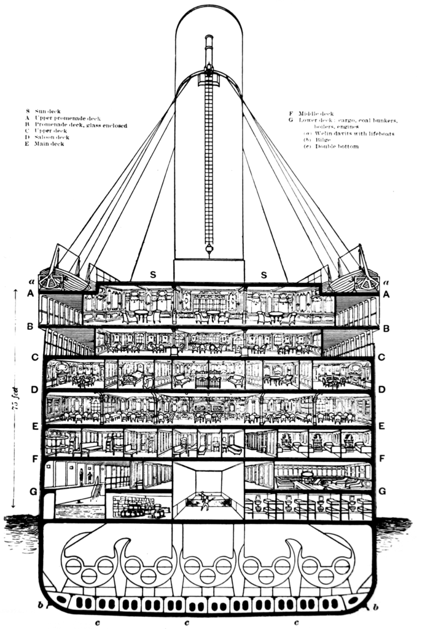

The Titanic was designed to carry 32 lifeboats, but this number was reduced to 20 (enough for about 1,180 people) for its maiden voyage – likely a cost-cutting measure influenced by perceptions that the additional boats would clutter the deck of a ship deemed “unsinkable.” Given that constraint, it is not surprising that a disproportionate number of men were apparently left aboard because of a [women and children first](http://en.wikipedia.org/wiki/Women_and_children_first) protocol followed by some of the officers overseeing the loading of lifeboats with passengers.

### Getting the Data Into R

Kaggle packaged the data for the Titanic challenge into two csv-format files: - **train.csv** (data containing attributes and known outcomes [survived or perished] for a subset of the passengers) - **test.csv** (data containing attributes *without* outcomes for a subset of passengers)

I’ve reviewed a *lot* of code containing approaches to sourcing data from a csv file with R. The majority seem to go no further than a simple read.csv function, mostly devoid of options, coded separately for each file being read. Later, the user often finds her/himself manually doing a number of tasks that could have been handled within the read function call. I chose to get as much out of `read.csv` as I could in the context of a re-usable custom function.

```r
setwd("~/GitHub/Titanic")
readData <- function(path.name, file.name, column.types, missing.types) {
  read.csv( url( paste(path.name, file.name, sep="") ),
            colClasses=column.types,
            na.strings=missing.types )
}
```

I’ve pushed the [Titanic csv files](https://github.com/wehrley/Kaggle_Titanic) to my GitHub account so that I can access the data from anywhere and, more importantly, demonstrate here the reading of data from a web source. Here are the arguments I will pass into this custom file reading function for the train.csv file:

```r
Titanic.path <- "https://raw.github.com/wehrley/Kaggle_Titanic/master/"
train.data.file <- "train.csv"
test.data.file <- "test.csv"
missing.types <- c("NA", "")
train.column.types <- c('integer',   # PassengerId
                        'factor',    # Survived
                        'factor',    # Pclass
                        'character', # Name
                        'factor',    # Sex
                        'numeric',   # Age
                        'integer',   # SibSp
                        'integer',   # Parch
                        'character', # Ticket
                        'numeric',   # Fare
                        'character', # Cabin
                        'factor'     # Embarked
)
test.column.types <- train.column.types[-2]     # # no Survived column in test.csv
```

Specifying missing types up front should make the data munging process a bit easier, and while I may have to change the class type for a data frame column or two along the way, I’ve specified class definitions in a manner which should be most conducive to modeling later. This leaves me with much cleaner code for reading the csv files.

```r
train.raw <- readData(Titanic.path, train.data.file,
                      train.column.types, missing.types)
df.train <- train.raw

test.raw <- readData(Titanic.path, test.data.file,
                     test.column.types, missing.types)
df.infer <- test.raw
```

### Data Munging

Josh Wills, senior director of data science at [Cloudera](http://www.cloudera.com/), described himself as a *data janitor* in [this interview](http://www.technologyreview.com/news/513866/in-a-data-deluge-companies-seek-to-fill-a-new-role/) from spring 2013. My experience in analytics projects over the years has certainly confirmed that data preparation accounts for the bulk of the effort. While some consider the process of getting data into an analysis-ready form as a sort of necessary evil, I’ve often derived value from “getting one’s hands dirty” and acquiring a granular view of the available data. Sometimes my greatest insights have come from this phase, often referred to as data pre-processing.

Let’s start with a look at missing data in the training set. I’ll use the `missmap` function from the [Amelia package](http://cran.r-project.org/web/packages/Amelia/) to display those.

```r
library(Amelia)
```

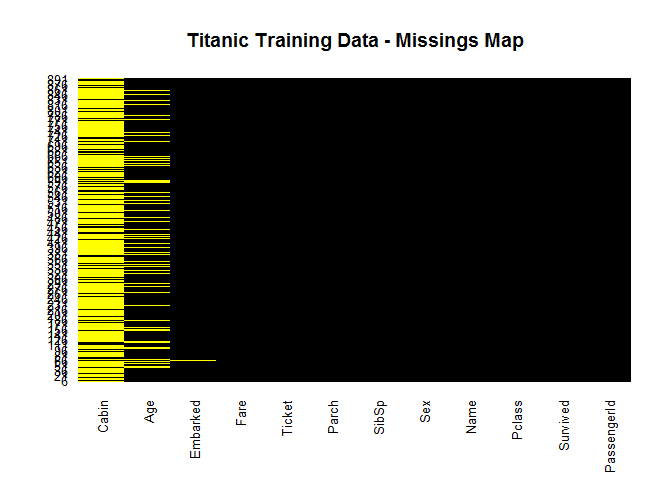

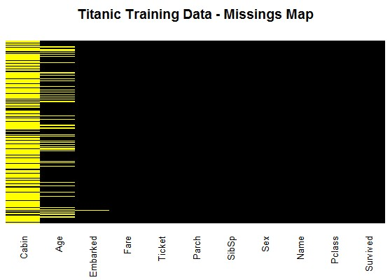

```r
## map missing data by provided feature
require(Amelia)
missmap(df.train, main="Titanic Training Data - Missings Map",
        col=c("yellow", "black"), legend=FALSE)
```

Roughly 20 percent of the Age data is missing, and well above 70 percent of the passengers cannot be linked to a specific cabin number. While the proportion of Age “missings” is likely small enough for reasonable replacement with some form of [imputation](http://en.wikipedia.org/wiki/Imputation_%28statistics%29), the cabin missings seem too extensive to make reliable imputation possible. Nevertheless, *some* data could be better than *zero* data, so I’ll look at cabin numbers later to see how we can put them to use.

Before we start filling in missing data, let’s see what can be learned from the data we have. Putting some simple data visualization tools to work can take us a long way toward understanding what might influence the outcome we’re trying to predict – in this case, whether or not a passenger survived. Below is some code and the graphs they produced:

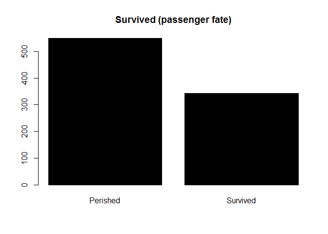

```r
barplot(table(df.train$Survived),
        names.arg = c("Perished", "Survived"),
        main="Survived (passenger fate)", col="black")
```

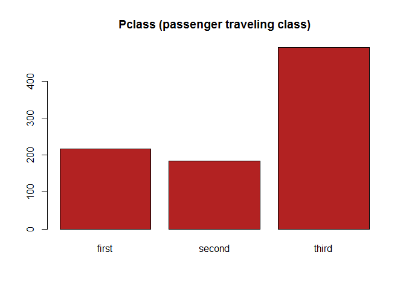

```r
barplot(table(df.train$Pclass),
        names.arg = c("first", "second", "third"),
        main="Pclass (passenger traveling class)", col="firebrick")
```

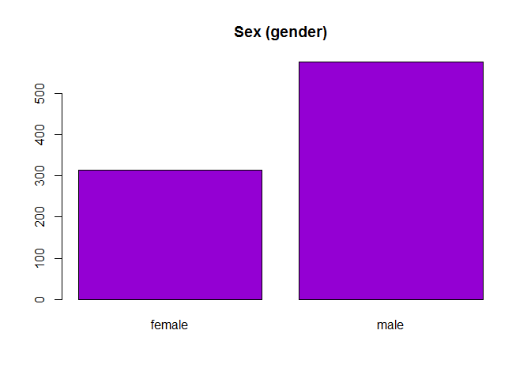

```r
barplot(table(df.train$Sex), main="Sex (gender)", col="darkviolet")
```

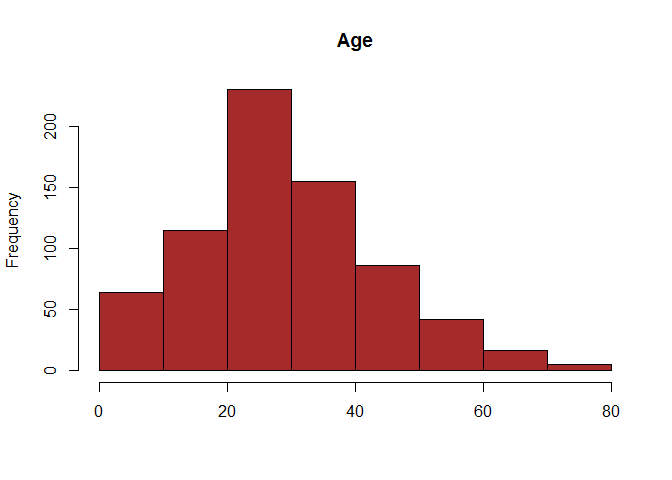

```r
hist(df.train$Age, main="Age", xlab = NULL, col="brown")
```

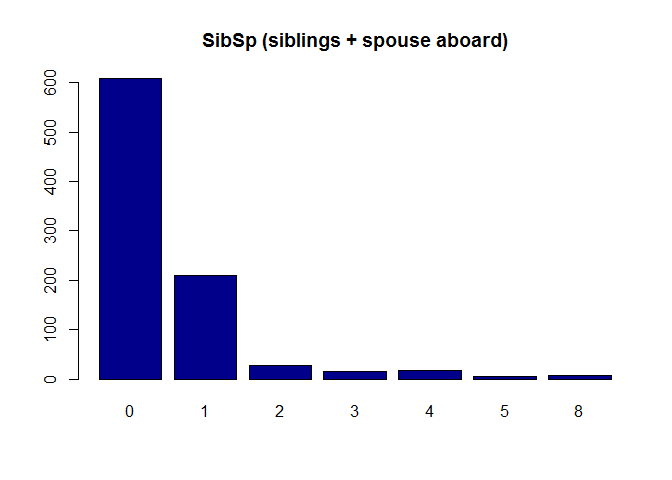

```r
barplot(table(df.train$SibSp), main="SibSp (siblings + spouse aboard)",
        col="darkblue")
```

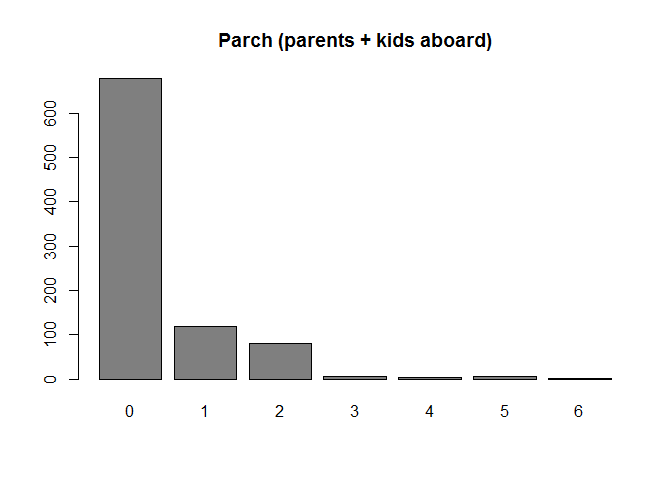

```r
barplot(table(df.train$Parch), main="Parch (parents + kids aboard)",
        col="gray50")
```

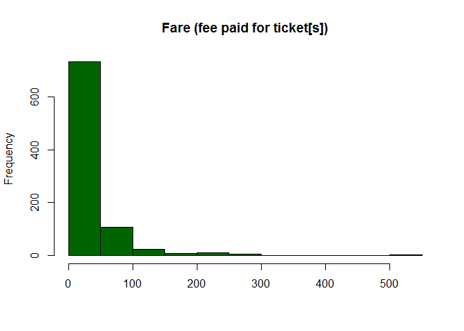

```r
hist(df.train$Fare, main="Fare (fee paid for ticket[s])", xlab = NULL,
     col="darkgreen")
```

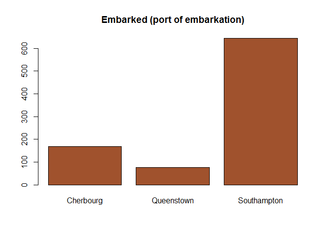

[figure not shown]

[figure not shown]

```r
barplot(table(df.train$Embarked),
        names.arg = c("Cherbourg", "Queenstown", "Southampton"),
        main="Embarked (port of embarkation)", col="sienna")
```

Note the dominant categories in the first three graphs: * more passengers perished than survived * about twice as many passengers in 3rd class than in either 1st or 2nd * male passengers far outnumbered females

Perhaps these are the first clues that the two themes discussed earlier – women and children first policy, and location on the ship – could dictate the feature set. Although the fact that Southampton was the port of embarkation for most passengers doesn’t make for a very balanced *Embarked* factor, it might mean something in the final analysis.

Mosaic plots offer an interesting – and arguably under-utilized – way to summarize data. The [vcd package](http://cran.r-project.org/web/packages/vcd/index.html) includes the `mosaicplot` function for creating those. The following mosaic suggests that traveling class did influence the odds of a passenger’s survival.

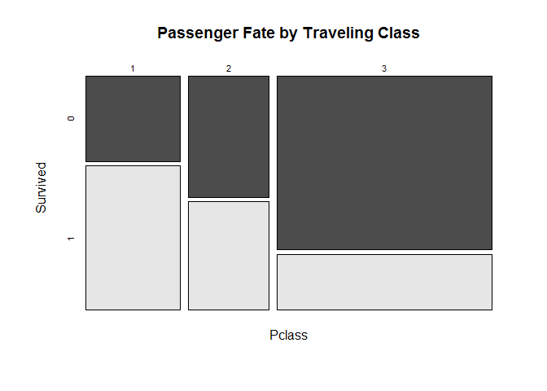

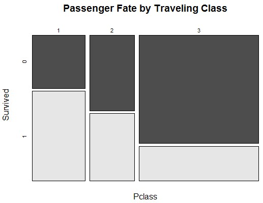

```r
mosaicplot(df.train$Pclass ~ df.train$Survived,
           main="Passenger Fate by Traveling Class", shade=FALSE,
           color=TRUE, xlab="Pclass", ylab="Survived")
```

Do you recall the earlier bar graph showing that some 2/3 of passengers were males? That is taken into account by the width of the two rectangles labeled “male” in the mosaic below. Now look at the *height* of the leftmost light gray rectangle [representing the proportion of females who survived] and compare it to the much shorter light gray rectange [representing proportion of males who survived]. Gender should certainly prove to be a prominent feature in the final model.

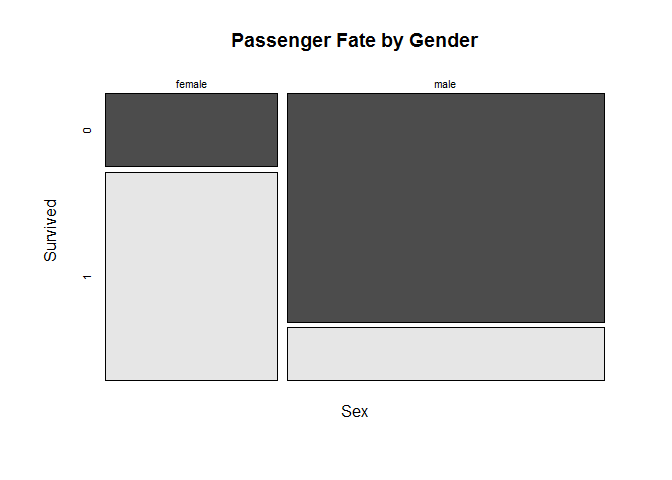

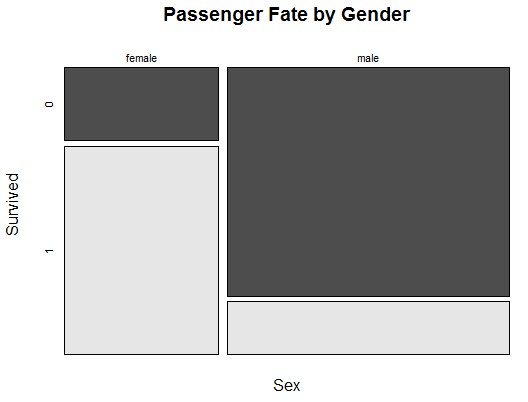

```r
mosaicplot(df.train$Sex ~ df.train$Survived,
           main="Passenger Fate by Gender", shade=FALSE, color=TRUE,
           xlab="Sex", ylab="Survived")
```

Is it possible that “survival of the fittest” dictated the fate of passengers in certain parts of the ship? Perhaps, though it isn’t apparent at first glance from the boxplot of Age by Survival.

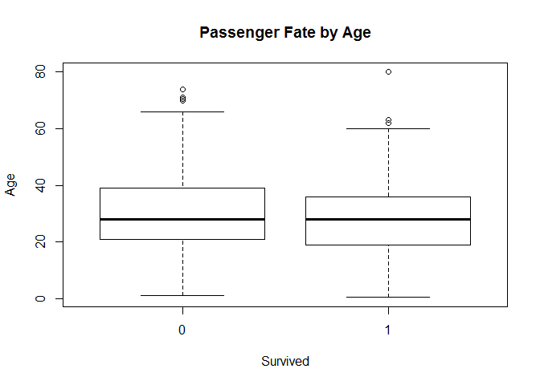

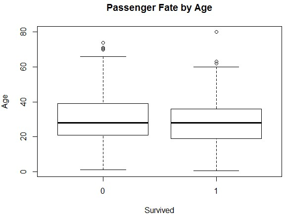

```r
boxplot(df.train$Age ~ df.train$Survived,
        main="Passenger Fate by Age",
        xlab="Survived", ylab="Age")
```

While passenger survival didn’t vary as much across the three ports of embarkation as it did between genders and traveling classes, perhaps the *Embarked* feature will prove useful at some point.

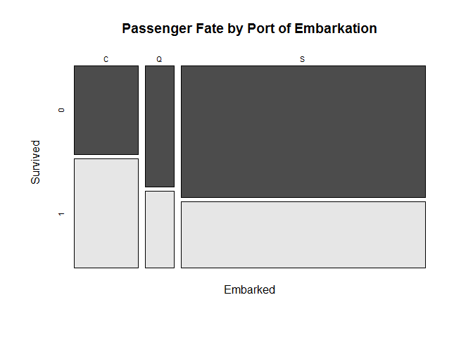

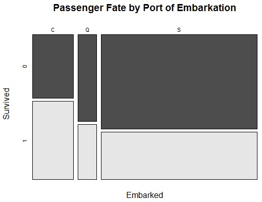

```r
mosaicplot(df.train$Embarked ~ df.train$Survived,
           main="Passenger Fate by Port of Embarkation",
           shade=FALSE, color=TRUE, xlab="Embarked", ylab="Survived")
```

Just one more graph, then we’ll get to those missing ages. The [corrgram package](http://cran.r-project.org/web/packages/corrgram/) is the source of a function for creating what is sometimes referred to as a correlogram. The one shown below confirms a couple of observations already made – namely, that survival odds drop with class, and age may not prove to be a significant predictor. Given that the upper class ranks tend to be represented by an older demographic, an inverse correlation between age and traveling class is to be expected. Although fare and class are closely related, it might be worth throwing the **Fare** feature into the mix as another way to define a passenger’s location on the ship.

```r
library(corrgram)
require(corrgram)
library(plyr) # for revalue
library(ada) # for ada (later)
corrgram.data <- df.train
## change features of factor type to numeric type for inclusion on correlogram
corrgram.data$Survived <- as.numeric(corrgram.data$Survived)
corrgram.data$Pclass <- as.numeric(corrgram.data$Pclass)
corrgram.data$Embarked <- revalue(corrgram.data$Embarked,
                                  c("C" = 1, "Q" = 2, "S" = 3))
## generate correlogram
corrgram.vars <- c("Survived", "Pclass", "Sex", "Age",
                   "SibSp", "Parch", "Fare", "Embarked")
corrgram(corrgram.data[,corrgram.vars], order=FALSE,
         lower.panel=panel.ellipse, upper.panel=panel.pie,
         text.panel=panel.txt, main="Titanic Training Data")
```

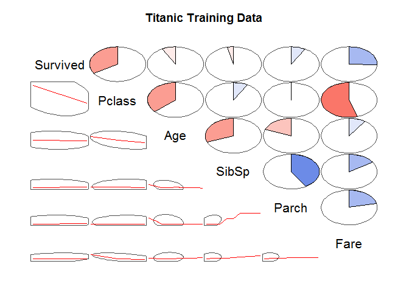

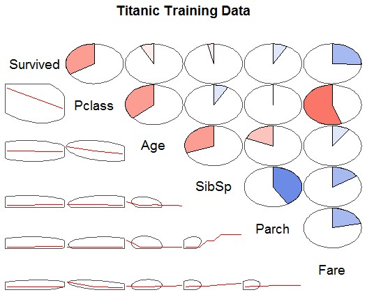

Time to tackle those missing ages. A common approach to this type of situation is to replacing the missings with the average of the available values. In this case, that would mean replacing 177 missing **Age** values with 29.7.

```r
summary(df.train$Age)
```

```
##    Min. 1st Qu.  Median    Mean 3rd Qu.    Max.    NA's
##    0.42   20.12   28.00   29.70   38.00   80.00     177
```